# Datenmengen

Daniel Zimmermann / David Lilek

# Data Simulation

- variable hospitalization: in this case random assignment may not be the best way because symptomatic disease progression would lead to higher hospitalization rates than aysmptomatic disease progression
- time from positive testing to hospital admission is needed for cox model
  - found this [article](https://www.ncbi.nlm.nih.gov/pmc/articles/PMC7589278/)
  - it is a bit age-depended but overall it seems to be right skewed
  - [here](https://stackoverflow.com/questions/28099590/create-sample-vector-data-in-r-with-a-skewed-distribution-with-limited-range) i found how to create skewed data-sets
- sex
  - it seems as stated below in the comments than men are higher affected than women but don’t know yet how to consider this in a useful way
- age
  - tried something but its random and doesnt take other variables into account

```r
#set.seed
set.seed(123)


#variant from tab1
alpha <- replicate(34656,"alpha")
delta <- replicate(8682,"delta")
variant <- sample(c(alpha, delta),replace = TRUE)

data <- data.frame(
  variant = c(alpha, delta),replace = TRUE)

#symptom status
asymptomatic_alpha <- replicate(14934,"asymptomatic")
symptomatic_alpha <- replicate(17757,"symptomatic")
unknown_alpha <- replicate(1965,"unknown")
asymptomatic_delta <- replicate(3659,"asymptomatic")
symptomatic_delta <- replicate(4334,"symptomatic")
unknown_delta <- replicate(689,"unknown")

stat_alpha <- c(asymptomatic_alpha,symptomatic_alpha,unknown_alpha)
stat_alpha <- sample(stat_alpha)
stat_delta <- c(asymptomatic_delta,symptomatic_delta,unknown_delta)
stat_delta <- sample(stat_delta)

data$stat <- ifelse(data$variant == "alpha", stat_alpha, stat_delta)

#check if it is correct
table(subset(data,variant="alpha"))
```

```
## , , stat = asymptomatic
##
##        replace
## variant  TRUE
##   alpha 14934
##   delta  3659
##
## , , stat = symptomatic
##
##        replace
## variant  TRUE
##   alpha 17757
##   delta  4334
##
## , , stat = unknown
##
##        replace
## variant  TRUE
##   alpha  1965
##   delta   689
```

```r
#hospitalisation
h_alpha <- replicate(764,"HOS")
h_delta <- replicate(196,"HOS")
er_alpha <- replicate(1148,"ER") #er = emergency care
er_delta <- replicate(498,"ER")

hos_alpha <- c(h_alpha,er_alpha)
hos_alpha <- sample(hos_alpha)

hos_delta <- c(h_delta,er_delta)
hos_delta <- sample(hos_delta)

#in this case random assignment isn't the best way because symptomatic disease progression would lead to higher hospitalization rates than aysmptomatic disease progression
data$hos=""
data$hos[sample(which(data$variant == "alpha"),length(hos_alpha))] <- hos_alpha
data$hos[sample(which(data$variant == "delta"),length(hos_delta))] <- hos_delta

#--------------------------------------------------------------------
######hospitalisation

#use categorial variables
h_alpha <- replicate(764,"HOS")
h_delta <- replicate(196,"HOS")
er_alpha <- replicate(1148,"ER") #er = emergency care
er_delta <- replicate(498,"ER")

#use integers 0=no hospitalisation, 1=hos, 2=er -> needed for cox regression
#1: Hospital admission within 14 days after specimen
#2: Hospital admission or emergency care attendance within 14 days after specimen
h_alpha <- replicate(764,1)
h_delta <- replicate(196,1)
er_alpha <- replicate(1148,2) #er = emergency care
er_delta <- replicate(498,2)

#combine and sample variable
hos_alpha <- c(h_alpha,er_alpha)
hos_alpha <- sample(hos_alpha)
hos_delta <- c(h_delta,er_delta)
hos_delta <- sample(hos_delta)

#in this case random assignment isn't the best way because symptomatic disease progression would lead to higher hospitalization rates than aysmptomatic disease progression
data$hos=0
data$hos[sample(which(data$variant == "alpha"),length(hos_alpha))] <- hos_alpha
data$hos[sample(which(data$variant == "delta"),length(hos_delta))] <- hos_delta

#-------------------------------------------------------------------
#create time of hospitalisation
#article days symptoms to admission hospital
#https://www.ncbi.nlm.nih.gov/pmc/articles/PMC7589278/
#because of this maybe skewed might be more suitable
#only people which are hospitaled get values all which data$hos==0 get a 0 value
data$time_equal=0
#equally distributed
data$time_equal[which(data$hos==1 | data$hos==2)]<-sample(5:14,length(hos_alpha)+length(hos_delta),replace = TRUE)
#right skewed
data$time_skewed=0
data$time_skewed[which(data$hos==1 | data$hos==2)]<-sample(rbeta((length(hos_alpha)+length(hos_delta)),2,6)*14)
#right skewed v002
# a bit different to get rid of hospitalzation on day 0-2
data$time_skewed_v002=0
data$time_skewed_v002[which(data$hos==1 | data$hos==2)]<-sample(rbeta((length(hos_alpha)+length(hos_delta)),2,6)*12+2)


#---------------------------------
#vaccination status
#Unvaccinated                                 0
#<21 days after first vaccination dose        1
#≥21 days after first vaccination dose        2
#≥14 days after second vaccination dose       3
vac_alpha <- replicate(25823,0)
vac_alpha <- c(vac_alpha,replicate(2206,1))
vac_alpha <- c(vac_alpha,replicate(6172,2))
vac_alpha <- c(vac_alpha,replicate(455,3))
vac_alpha <- sample(vac_alpha)
vac_delta <- replicate(6255,0)
vac_delta <- c(vac_delta,replicate(426,1))
vac_delta <- c(vac_delta,replicate(1662,2))
vac_delta <- c(vac_delta,replicate(339,3))
vac_delta <- sample(vac_delta)

data$vac=NA
data$vac[sample(which(data$variant == "alpha"),length(vac_alpha))] <- vac_alpha
data$vac[sample(which(data$variant == "delta"),length(vac_delta))] <- vac_delta
#check if it is correct
#table(data$vac[which(data$variant=="alpha")])
#table(data$vac[which(data$variant=="delta")])
data$vac_update <- data$vac
data$vac_update[data$vac<1]<-1
data$vac_update[data$vac>2]<-2

#-----------------------------------------------------------
#sex
#it seems that men are more affected than women
#In the public data set, the number of men who died from COVID-19 is 2.4 times that of women
#https://www.worldometers.info/coronavirus/coronavirus-age-sex-demographics/
#https://www.frontiersin.org/articles/10.3389/fpubh.2020.00152/full
#https://www.nature.com/articles/s41467-020-19741-6
#now the code randomly assings male and female to the status and didnt account for the statement above
female_alpha <- replicate(17913,1)
female_delta <- replicate(4249,1)
male_alpha <- replicate(16743,2)
male_delta <- replicate(4433,2)
sex_delta <- c(female_delta,male_delta)
sex_delta <- sample(sex_delta)
sex_alpha <- c(female_alpha,male_alpha)
sex_alpha <- sample(sex_alpha)

data$sex=0
data$sex[sample(which(data$variant == "alpha"),length(sex_alpha))] <- sex_alpha
data$sex[sample(which(data$variant == "delta"),length(sex_delta))] <- sex_delta

#check if it is correct
#table(data$sex[which(data$variant=="alpha")])
#table(data$sex[which(data$variant=="delta")])

#----------------------------------------------------------------
#age
a1 <- sample(0:9,3564, replace = TRUE)
a2 <- sample(10:19,9462, replace = TRUE)
a3 <- sample(20:29,7636, replace = TRUE)
a4 <- sample(30:39,9157, replace = TRUE)
a5 <- sample(40:49,6885, replace = TRUE)
a6 <- sample(50:59,3916, replace = TRUE)
a7 <- sample(60:69,1681, replace = TRUE)
a8 <- sample(70:79,584, replace = TRUE)
a9 <- sample(80:100,453, replace = TRUE)
age <- c(a1,a2,a3,a4,a5,a6,a7,a8,a9)
age <- sample(age)
data$age <- age
```

# Visualization

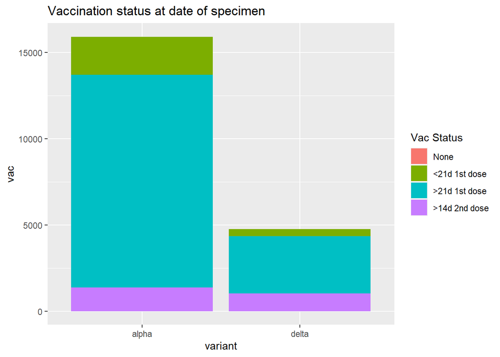

```r
library(ggplot2)
#vaccination status
p<-ggplot(data=data, aes(fill=factor(vac), x=variant, y=vac)) +
  geom_bar(stat="identity")+
  scale_fill_discrete(name = "Vac Status", labels = c("None", "<21d 1st dose", ">21d 1st dose",">14d 2nd dose"))+
  ggtitle("Vaccination status at date of specimen")
p
```

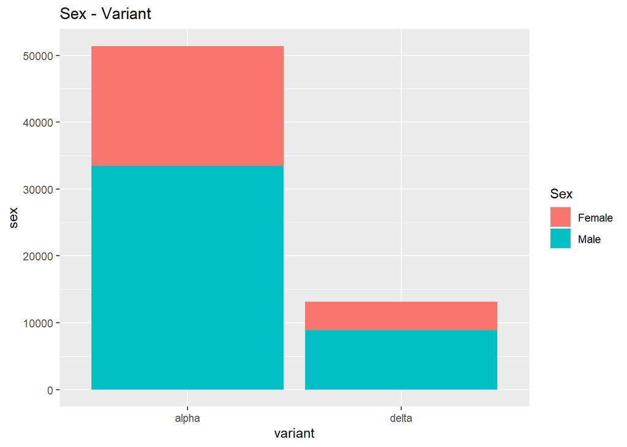

```r
#sex variant
p<-ggplot(data=data, aes(fill=factor(sex), x=variant, y=sex)) +
  geom_bar(stat="identity")+
  scale_fill_discrete(name = "Sex", labels = c("Female", "Male"))+
  ggtitle("Sex - Variant")
p
```

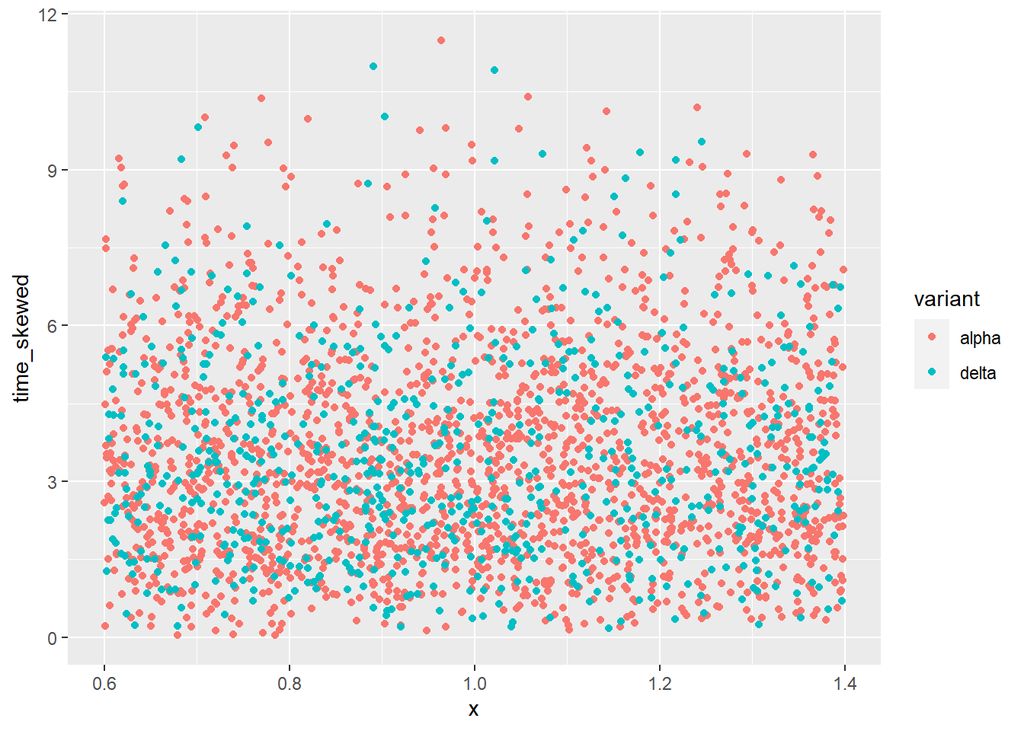

```r
#time of hospitalisation
p <- ggplot() +
    geom_jitter(data=data[which(data$time_skewed>0),], aes(x=1, y=time_skewed, color=variant))
p
```

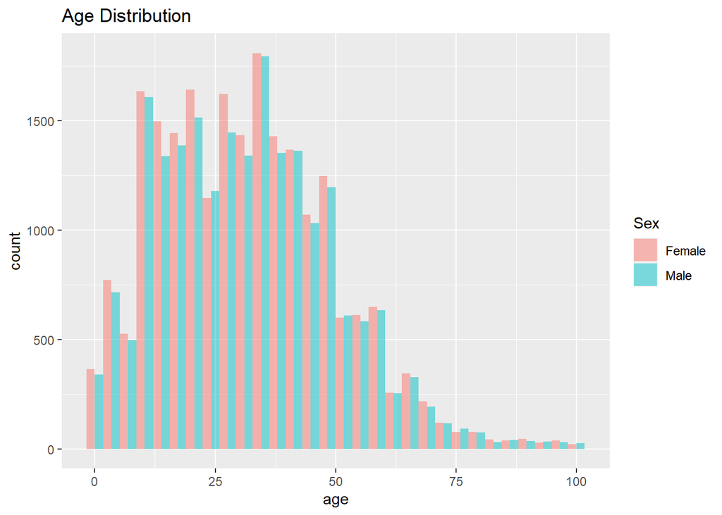

```r
# age
p<-ggplot(data, aes(x=age, fill=factor(sex))) +
  geom_histogram(alpha = 0.5, position = "dodge")+
  theme(legend.position="right")+
  scale_fill_discrete(name = "Sex", labels = c("Female", "Male"))+
  ggtitle("Age Distribution")
p
```

# Cox Regression

- [CoxRegression](http://www.sthda.com/english/wiki/cox-proportional-hazards-model)
- [CoxRegression](https://sphweb.bumc.bu.edu/otlt/mph-modules/bs/bs704_survival/BS704_Survival6.html)
- [CoxModelAssumptions](http://www.sthda.com/english/wiki/cox-model-assumptions)
- [Creating Survival Plots - Cheat Sheet](https://raw.githubusercontent.com/rstudio/cheatsheets/main/survminer.pdf)
- [CoxRegression nice plotting example](https://rviews.rstudio.com/2017/09/25/survival-analysis-with-r/)

## Cox Regression Table2

- MISSING: adjusted p value: regression adjustment for
  - age (linear)
  - date (linear)
  - sex
  - index of multiple deprivation
  - and international traveller status.

### Frist try

- table2 I used 0,1,2 for hospitalization
- but it should be 2 models 0-1 and 0-2
- in this first try I tested 3 different time simulations: equal, skewed, skewed_v002
- for this first try I also tested the assumptions

```r
#---------------------------------------------------------------
#Cox Regression

library("survival")
library("survminer")

#example data
# lung <- lung
# head(lung)
# res.cox <- coxph(Surv(time, status) ~ sex, data = lung)
# res.cox
# summary(res.cox)

#own data equal distributed
res.cox_equal <- coxph(Surv(time_equal,hos)~variant, data = data)
summary(res.cox_equal)
```

```
## Call:
## coxph(formula = Surv(time_equal, hos) ~ variant, data = data)
##
##   n= 2606, number of events= 1646
##    (40732 observations deleted due to missingness)
##
##                 coef exp(coef) se(coef)     z Pr(>|z|)
## variantdelta 0.23738   1.26793  0.05367 4.423 9.73e-06 ***
## ---
## Signif. codes:  0 '***' 0.001 '**' 0.01 '*' 0.05 '.' 0.1 ' ' 1
##
##              exp(coef) exp(-coef) lower .95 upper .95
## variantdelta     1.268     0.7887     1.141     1.409
##
## Concordance= 0.529  (se = 0.007 )
## Likelihood ratio test= 18.93  on 1 df,   p=1e-05
## Wald test            = 19.56  on 1 df,   p=1e-05
## Score (logrank) test = 19.66  on 1 df,   p=9e-06
```

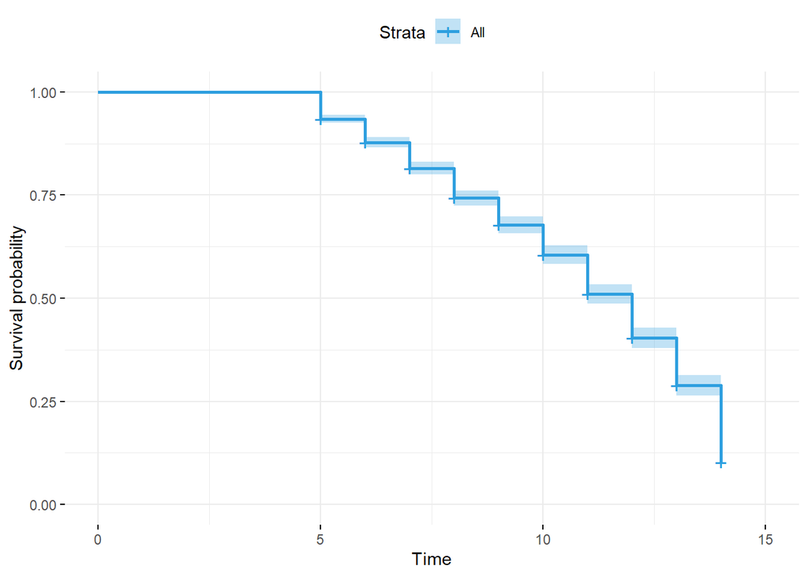

```r
ggsurvplot(survfit(res.cox_equal), data = data, palette = "#2E9FDF",
           ggtheme = theme_minimal())
```

```r
#own data right skewed
res.cox_skewed <- coxph(Surv(time_skewed,hos)~variant, data = data)
summary(res.cox_skewed)
```

```
## Call:
## coxph(formula = Surv(time_skewed, hos) ~ variant, data = data)
##
##   n= 2606, number of events= 1646
##    (40732 observations deleted due to missingness)
##
##                 coef exp(coef) se(coef)     z Pr(>|z|)
## variantdelta 0.24142   1.27305  0.05373 4.493 7.01e-06 ***
## ---
## Signif. codes:  0 '***' 0.001 '**' 0.01 '*' 0.05 '.' 0.1 ' ' 1
##
##              exp(coef) exp(-coef) lower .95 upper .95
## variantdelta     1.273     0.7855     1.146     1.414
##
## Concordance= 0.527  (se = 0.006 )
## Likelihood ratio test= 19.53  on 1 df,   p=1e-05
## Wald test            = 20.19  on 1 df,   p=7e-06
## Score (logrank) test = 20.29  on 1 df,   p=7e-06
```

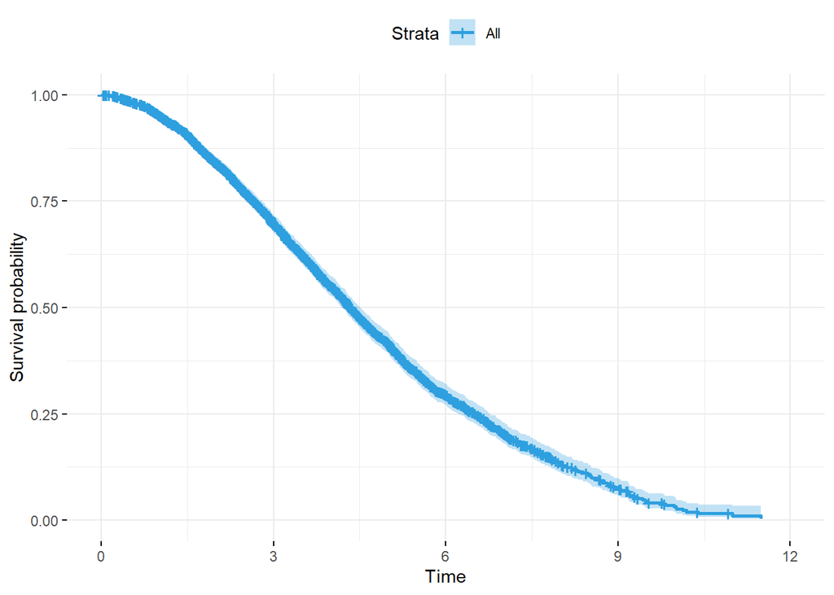

```r
ggsurvplot(survfit(res.cox_skewed), data = data, palette = "#2E9FDF",
           ggtheme = theme_minimal())
```

```r
#own data right skewed
res.cox_skewed_v002 <- coxph(Surv(time_skewed_v002,hos)~variant, data = data)
summary(res.cox_skewed_v002)
```

```
## Call:
## coxph(formula = Surv(time_skewed_v002, hos) ~ variant, data = data)
##
##   n= 2606, number of events= 1646
##    (40732 observations deleted due to missingness)
##
##                 coef exp(coef) se(coef)     z Pr(>|z|)
## variantdelta 0.19540   1.21580  0.05369 3.639 0.000273 ***
## ---
## Signif. codes:  0 '***' 0.001 '**' 0.01 '*' 0.05 '.' 0.1 ' ' 1
##
##              exp(coef) exp(-coef) lower .95 upper .95
## variantdelta     1.216     0.8225     1.094     1.351
##
## Concordance= 0.519  (se = 0.006 )
## Likelihood ratio test= 12.9  on 1 df,   p=3e-04
## Wald test            = 13.25  on 1 df,   p=3e-04
## Score (logrank) test = 13.29  on 1 df,   p=3e-04
```

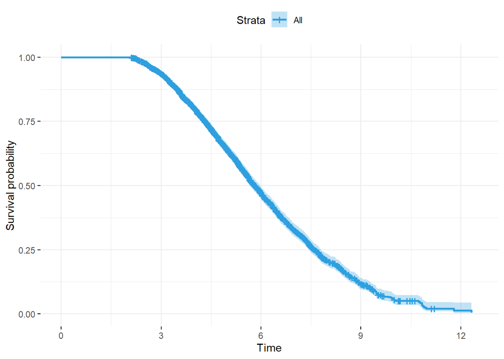

```r
ggsurvplot(survfit(res.cox_skewed_v002), data = data, palette = "#2E9FDF",
           ggtheme = theme_minimal())
```

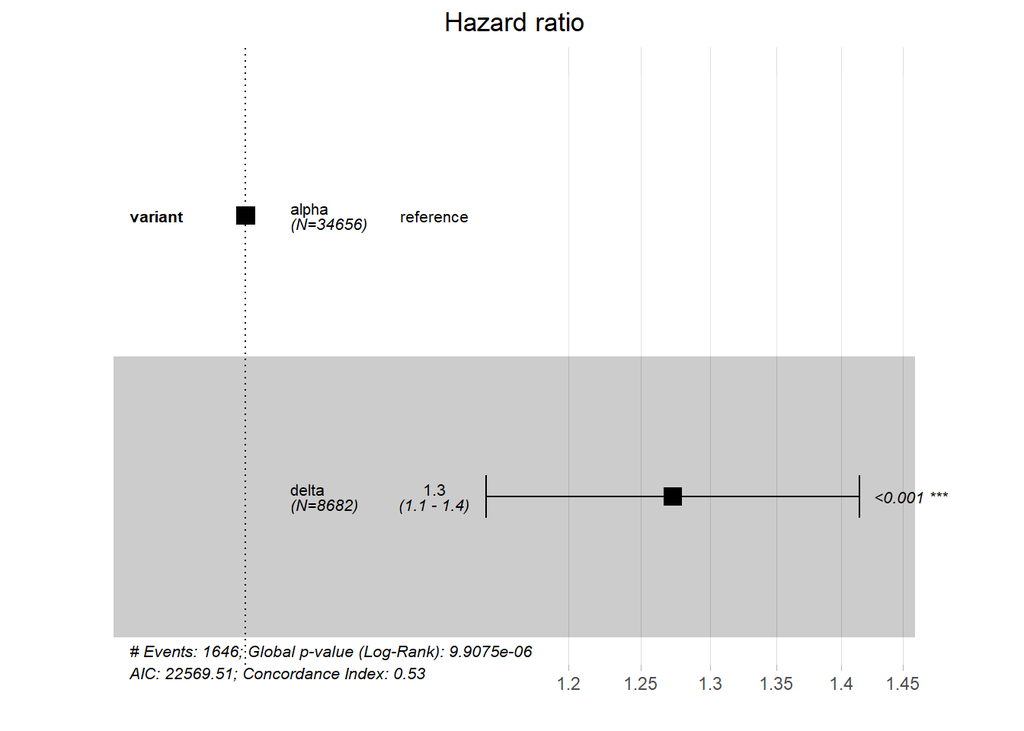

```r
# visualize hazard ratio
ggforest(res.cox_skewed, data = data)
```

- Testing the [Assumptions](http://www.sthda.com/english/wiki/cox-model-assumptions)
  - p values should be higher than 0.05 (significance level)

```r
test.ph <- cox.zph(res.cox_skewed)
test.ph
```

```
##         chisq df    p
## variant 0.765  1 0.38
## GLOBAL  0.765  1 0.38
```

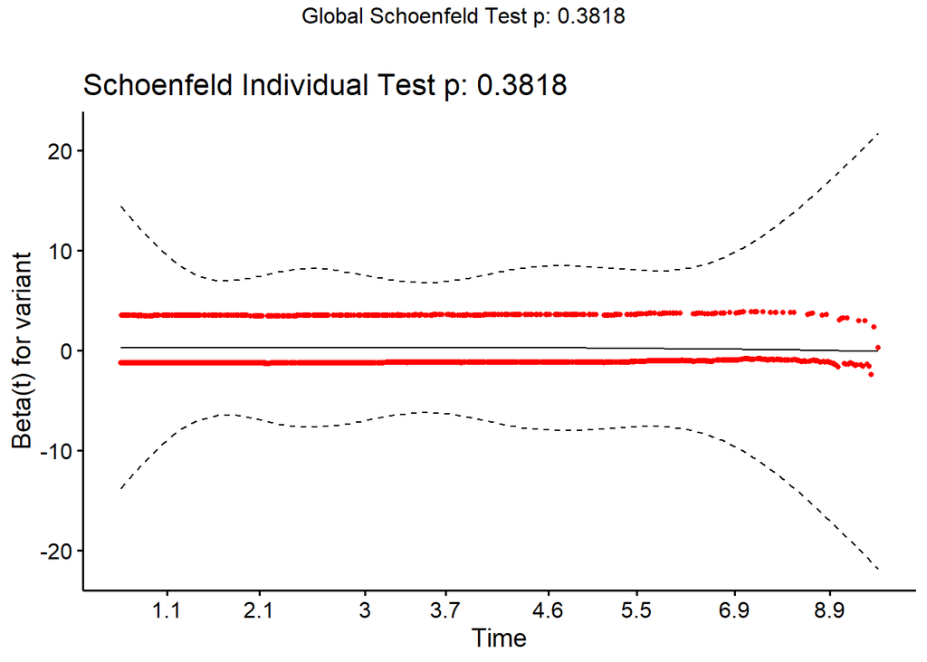

```r
ggcoxzph(test.ph)
```

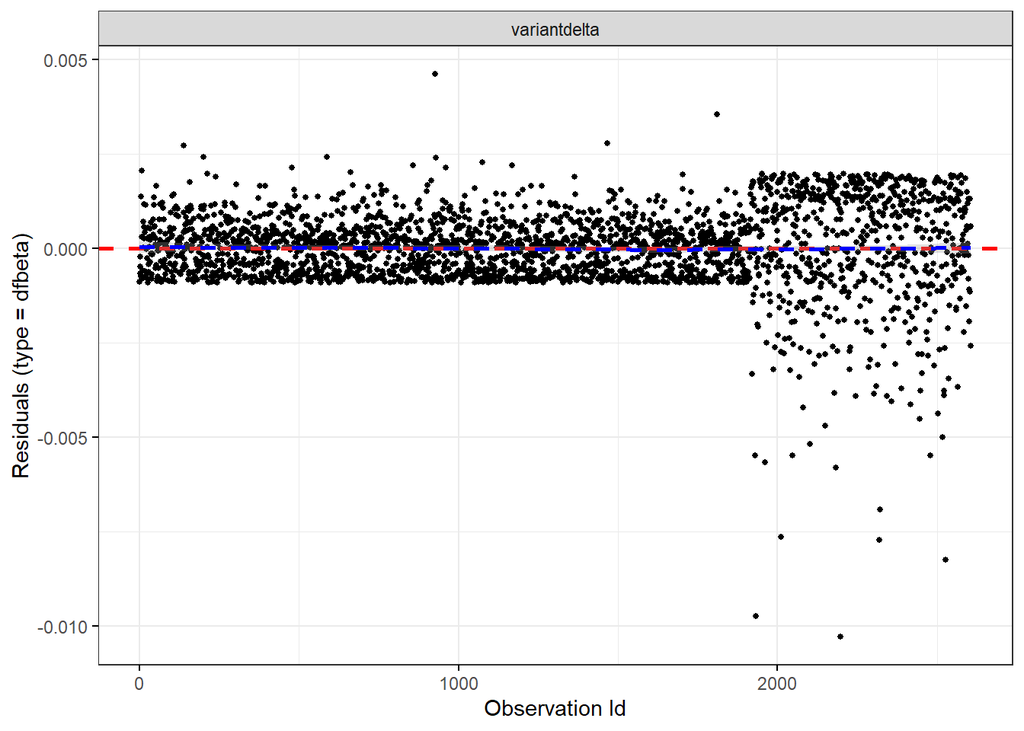

```r
ggcoxdiagnostics(res.cox_skewed, type = "dfbeta",
                 linear.predictions = FALSE, ggtheme = theme_bw())
```

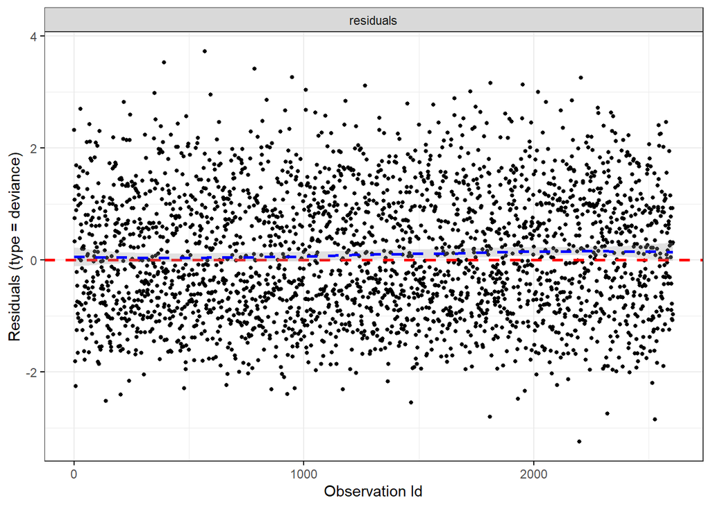

```r
ggcoxdiagnostics(res.cox_skewed, type = "deviance",
                 linear.predictions = FALSE, ggtheme = theme_bw())
```

### Second try

- here I built 2 models which is exactly what we want
- first model uses hos==1
  - in the paper they get a HR of 1·03 (0·88–1·21)
  - we got 0.9608 (0.8208-1.125)
- second model uses Hos==2
  - in the paper they get a HR of 1·39 (1·25–1·53)
  - we got 1.121 (1.009-1.246)

```r
#---------------------------------------------------------------
#Cox Regression
#own data right skewed
res.cox_skewed <- coxph(Surv(time_skewed,hos)~variant, data = data[data$hos==1,])
summary(res.cox_skewed)
```

```
## Call:
## coxph(formula = Surv(time_skewed, hos) ~ variant, data = data[data$hos ==
##     1, ])
##
##   n= 960, number of events= 960
##
##                  coef exp(coef) se(coef)      z Pr(>|z|)
## variantdelta -0.03995   0.96084  0.08035 -0.497    0.619
##
##              exp(coef) exp(-coef) lower .95 upper .95
## variantdelta    0.9608      1.041    0.8208     1.125
##
## Concordance= 0.506  (se = 0.007 )
## Likelihood ratio test= 0.25  on 1 df,   p=0.6
## Wald test            = 0.25  on 1 df,   p=0.6
## Score (logrank) test = 0.25  on 1 df,   p=0.6
```

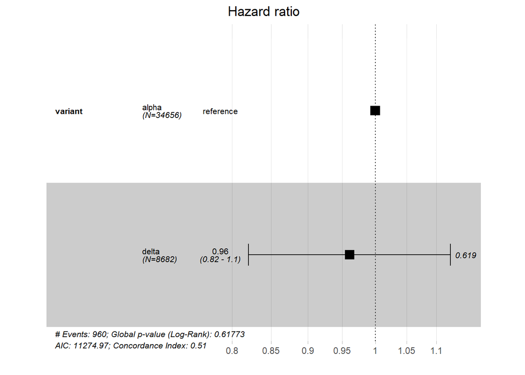

```r
# visualize hazard ratio
ggforest(res.cox_skewed, data = data)
```

```r
#---------------------------------------------------------------
#Cox Regression
#own data right skewed
res.cox_skewed <- coxph(Surv(time_skewed,hos)~variant, data = data[data$hos==2,])
summary(res.cox_skewed)
```

```
## Call:
## coxph(formula = Surv(time_skewed, hos) ~ variant, data = data[data$hos ==
##     2, ])
##
##   n= 1646, number of events= 1646
##
##                 coef exp(coef) se(coef)     z Pr(>|z|)
## variantdelta 0.11464   1.12147  0.05374 2.133   0.0329 *
## ---
## Signif. codes:  0 '***' 0.001 '**' 0.01 '*' 0.05 '.' 0.1 ' ' 1
##
##              exp(coef) exp(-coef) lower .95 upper .95
## variantdelta     1.121     0.8917     1.009     1.246
##
## Concordance= 0.512  (se = 0.006 )
## Likelihood ratio test= 4.48  on 1 df,   p=0.03
## Wald test            = 4.55  on 1 df,   p=0.03
## Score (logrank) test = 4.56  on 1 df,   p=0.03
```

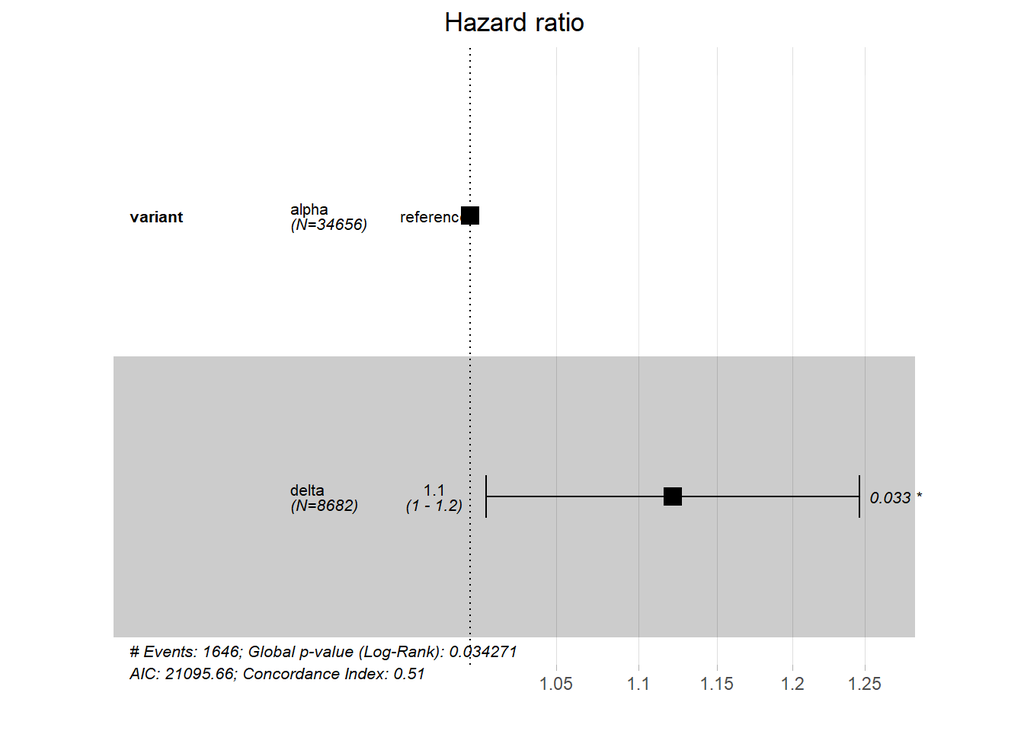

```r
# visualize hazard ratio
ggforest(res.cox_skewed, data = data)
```

### Table 2 - adjusted p values

- here I only simulated sex and take this into account

```r
#res.cox <- coxph(Surv(time, status) ~ age + sex + ph.ecog, data =  lung)
#own data right skewed
res.cox_skewed <- coxph(Surv(time_skewed,hos,sex)~variant, data = data[data$hos==1,])
summary(res.cox_skewed)
```

```
## Call:
## coxph(formula = Surv(time_skewed, hos, sex) ~ variant, data = data[data$hos ==
##     1, ])
##
##   n= 82, number of events= 39
##    (878 observations deleted due to missingness)
##
##                coef exp(coef) se(coef)     z Pr(>|z|)
## variantdelta 0.0847    1.0884   0.3966 0.214    0.831
##
##              exp(coef) exp(-coef) lower .95 upper .95
## variantdelta     1.088     0.9188    0.5003     2.368
##
## Concordance= 0.51  (se = 0.044 )
## Likelihood ratio test= 0.04  on 1 df,   p=0.8
## Wald test            = 0.05  on 1 df,   p=0.8
## Score (logrank) test = 0.05  on 1 df,   p=0.8
```

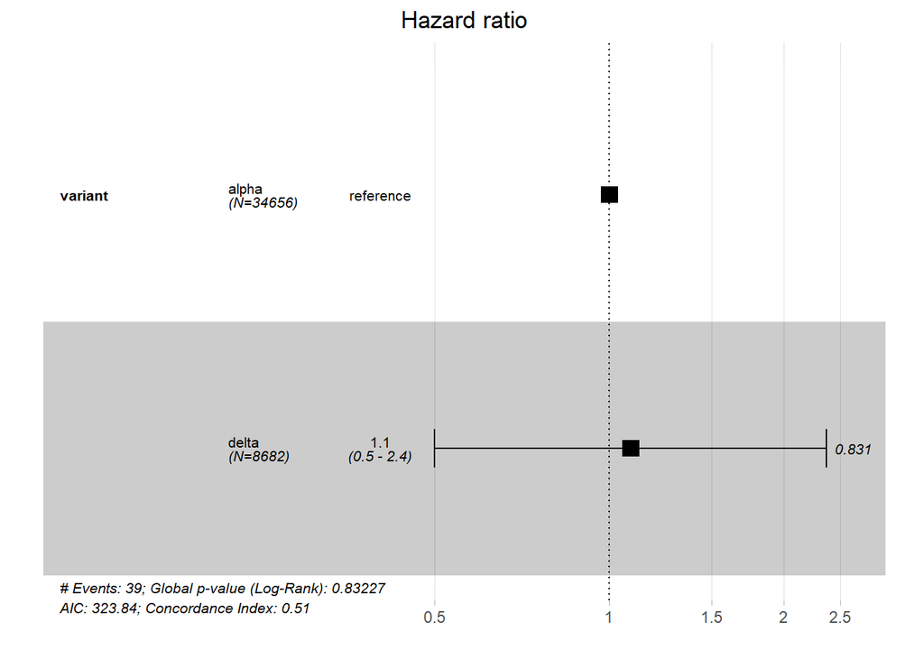

```r
# visualize hazard ratio
ggforest(res.cox_skewed, data = data)
```

## Cox Regression Table 3

### Used hos=1 and vac<2

- hos=1:
- vac<2 means: Unvaccinated or <21 days after first vaccination dose
- don’t know which one is correct: data$vac contains 0 and 1 and I put all 0 and 1 in a new column vac_update and coded it with 1 -> this leads to different results

```r
#skewed data
#skewed data
res.cox_vac <- coxph(Surv(time_skewed,vac)~variant, data = data[data$hos==1 & data$vac <2,])
summary(res.cox_vac)
```

```
## Call:
## coxph(formula = Surv(time_skewed, vac) ~ variant, data = data[data$hos ==
##     1 & data$vac < 2, ])
##
##   n= 767, number of events= 59
##
##                 coef exp(coef) se(coef)      z Pr(>|z|)
## variantdelta -0.4769    0.6207   0.3803 -1.254     0.21
##
##              exp(coef) exp(-coef) lower .95 upper .95
## variantdelta    0.6207      1.611    0.2945     1.308
##
## Concordance= 0.549  (se = 0.021 )
## Likelihood ratio test= 1.76  on 1 df,   p=0.2
## Wald test            = 1.57  on 1 df,   p=0.2
## Score (logrank) test = 1.6  on 1 df,   p=0.2
```

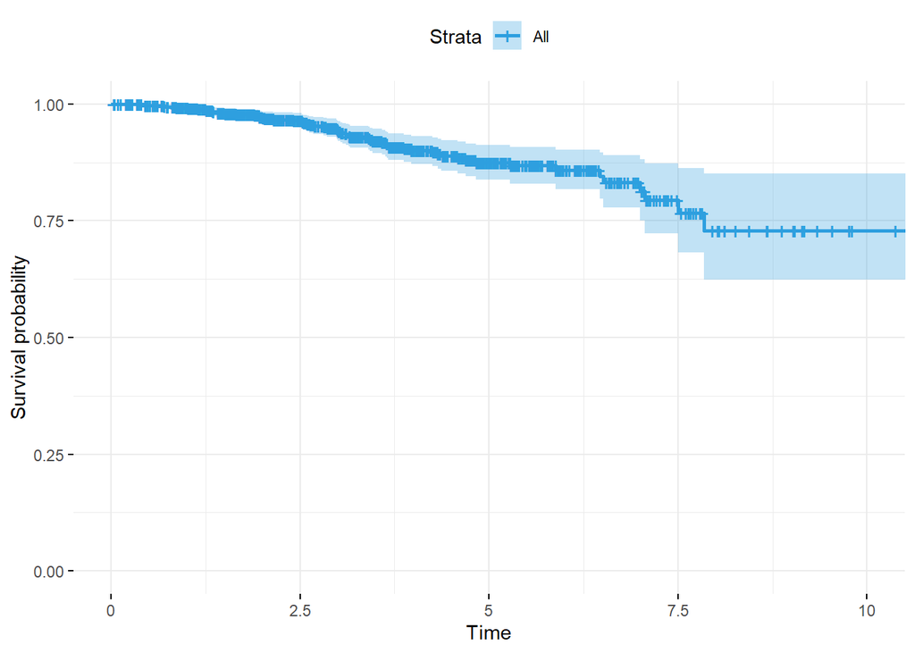

```r
ggsurvplot(survfit(res.cox_vac), data = data, palette = "#2E9FDF",
           ggtheme = theme_minimal())
```

### used hos=1 and vac_update == 1

```r
#skewed data
#skewed data
res.cox_vac <- coxph(Surv(time_skewed,vac_update)~variant, data = data[data$hos==1 & data$vac_update == 1,])
summary(res.cox_vac)
```

```
## Call:
## coxph(formula = Surv(time_skewed, vac_update) ~ variant, data = data[data$hos ==
##     1 & data$vac_update == 1, ])
##
##   n= 767, number of events= 767
##
##                  coef exp(coef) se(coef)      z Pr(>|z|)
## variantdelta -0.02332   0.97695  0.09032 -0.258    0.796
##
##              exp(coef) exp(-coef) lower .95 upper .95
## variantdelta    0.9769      1.024    0.8185     1.166
##
## Concordance= 0.501  (se = 0.008 )
## Likelihood ratio test= 0.07  on 1 df,   p=0.8
## Wald test            = 0.07  on 1 df,   p=0.8
## Score (logrank) test = 0.07  on 1 df,   p=0.8
```

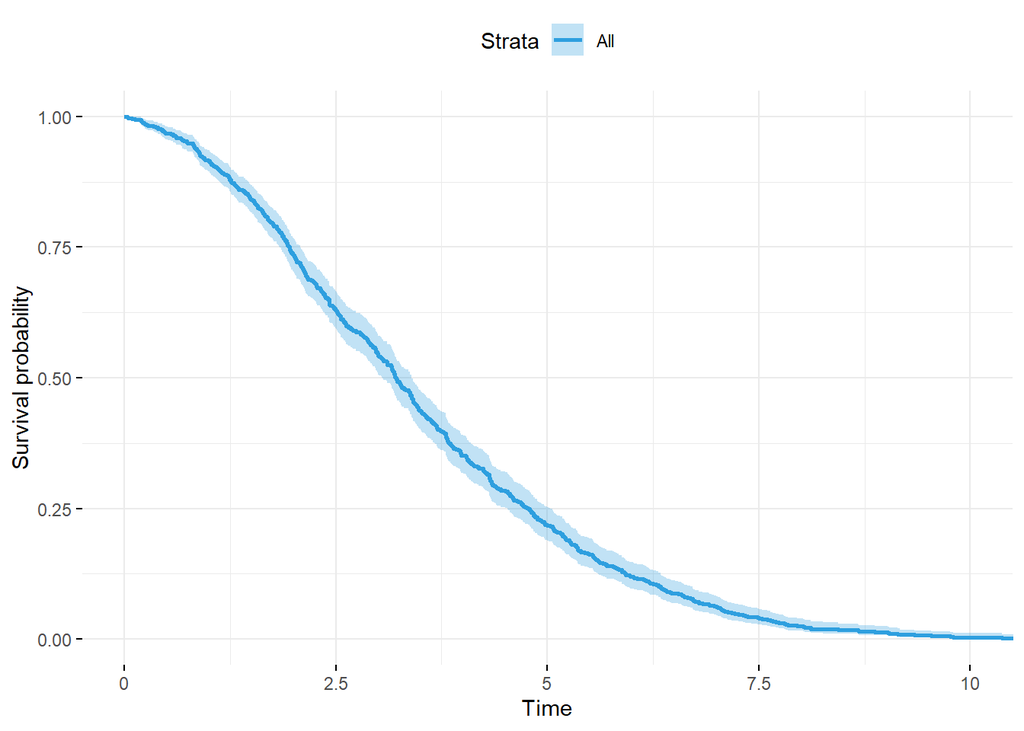

```r
ggsurvplot(survfit(res.cox_vac), data = data, palette = "#2E9FDF",
           ggtheme = theme_minimal())
```

### used hos=1 and vac_update == 2

```r
#skewed data
#skewed data
res.cox_vac <- coxph(Surv(time_skewed,vac_update)~variant, data = data[data$hos==1 & data$vac_update == 2,])
summary(res.cox_vac)
```

```
## Call:
## coxph(formula = Surv(time_skewed, vac_update) ~ variant, data = data[data$hos ==
##     1 & data$vac_update == 2, ])
##
##   n= 193, number of events= 193
##
##                  coef exp(coef) se(coef)      z Pr(>|z|)
## variantdelta -0.06762   0.93462  0.17675 -0.383    0.702
##
##              exp(coef) exp(-coef) lower .95 upper .95
## variantdelta    0.9346       1.07     0.661     1.322
##
## Concordance= 0.523  (se = 0.016 )
## Likelihood ratio test= 0.15  on 1 df,   p=0.7
## Wald test            = 0.15  on 1 df,   p=0.7
## Score (logrank) test = 0.15  on 1 df,   p=0.7
```

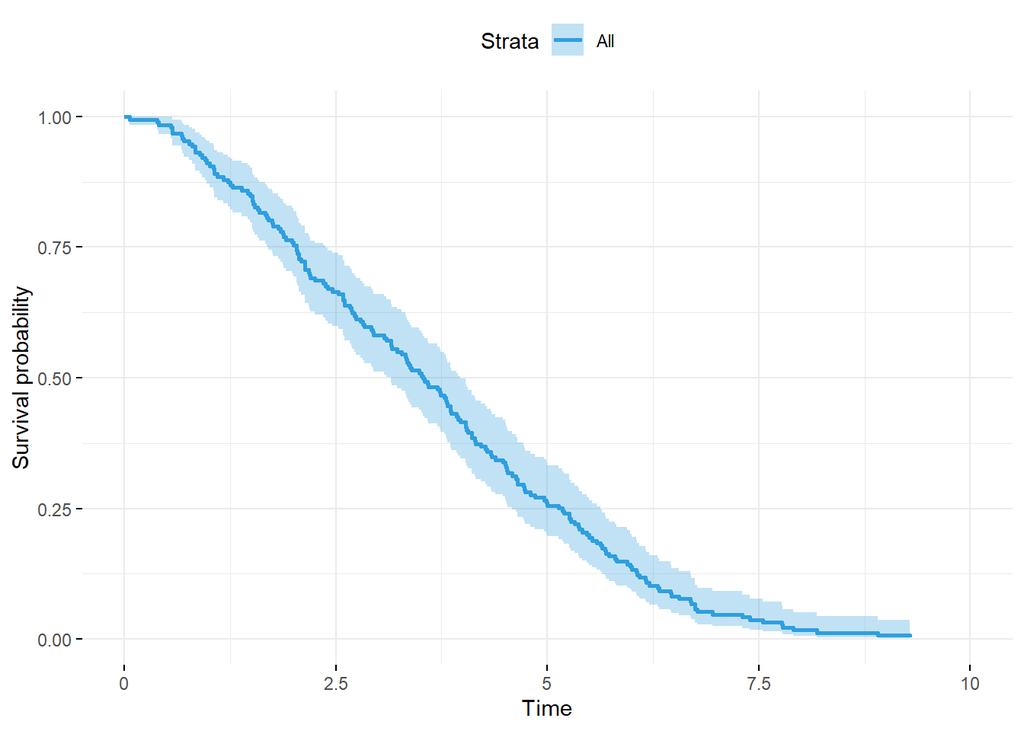

```r
ggsurvplot(survfit(res.cox_vac), data = data, palette = "#2E9FDF",
           ggtheme = theme_minimal())
```

### used hos=2 and vac<2

- hos=2:
- vac<2 means: Unvaccinated or <21 days after first vaccination dose

```r
#skewed data
res.cox_vac <- coxph(Surv(time_skewed,vac)~variant, data = data[data$hos==2 & data$vac <2,])
summary(res.cox_vac)
```

```
## Call:
## coxph(formula = Surv(time_skewed, vac) ~ variant, data = data[data$hos ==
##     2 & data$vac < 2, ])
##
##   n= 1311, number of events= 88
##
##                  coef exp(coef) se(coef)      z Pr(>|z|)
## variantdelta -0.07439   0.92831  0.24665 -0.302    0.763
##
##              exp(coef) exp(-coef) lower .95 upper .95
## variantdelta    0.9283      1.077    0.5725     1.505
##
## Concordance= 0.499  (se = 0.028 )
## Likelihood ratio test= 0.09  on 1 df,   p=0.8
## Wald test            = 0.09  on 1 df,   p=0.8
## Score (logrank) test = 0.09  on 1 df,   p=0.8
```

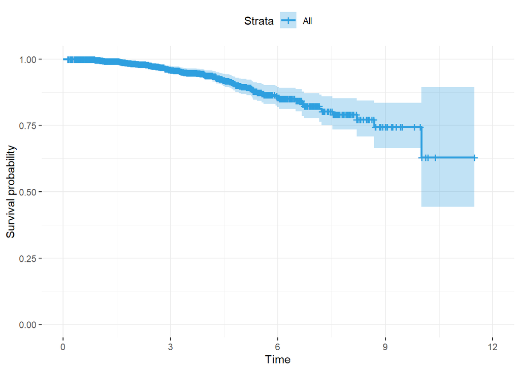

```r
ggsurvplot(survfit(res.cox_vac), data = data, palette = "#2E9FDF",
           ggtheme = theme_minimal())
```

### hos =1 vac == 2

- hos=1:
- vac>1 means: ≥21 days after first vaccination dose with or without second vaccination dose
- `data$vac > 2` this doesn’t work yet but don’t know why
- `data$vac == 2` works but I think we also want `data$vac==3`

```r
#skewed data
res.cox_vac <- coxph(Surv(time_skewed,vac)~variant, data = data[data$hos==1 & data$vac == 2,])
summary(res.cox_vac)
```

```
## Call:
## coxph(formula = Surv(time_skewed, vac) ~ variant, data = data[data$hos ==
##     1 & data$vac == 2, ])
##
##   n= 179, number of events= 179
##
##                  coef exp(coef) se(coef)      z Pr(>|z|)
## variantdelta -0.04572   0.95531  0.18909 -0.242    0.809
##
##              exp(coef) exp(-coef) lower .95 upper .95
## variantdelta    0.9553      1.047    0.6595     1.384
##
## Concordance= 0.516  (se = 0.016 )
## Likelihood ratio test= 0.06  on 1 df,   p=0.8
## Wald test            = 0.06  on 1 df,   p=0.8
## Score (logrank) test = 0.06  on 1 df,   p=0.8
```

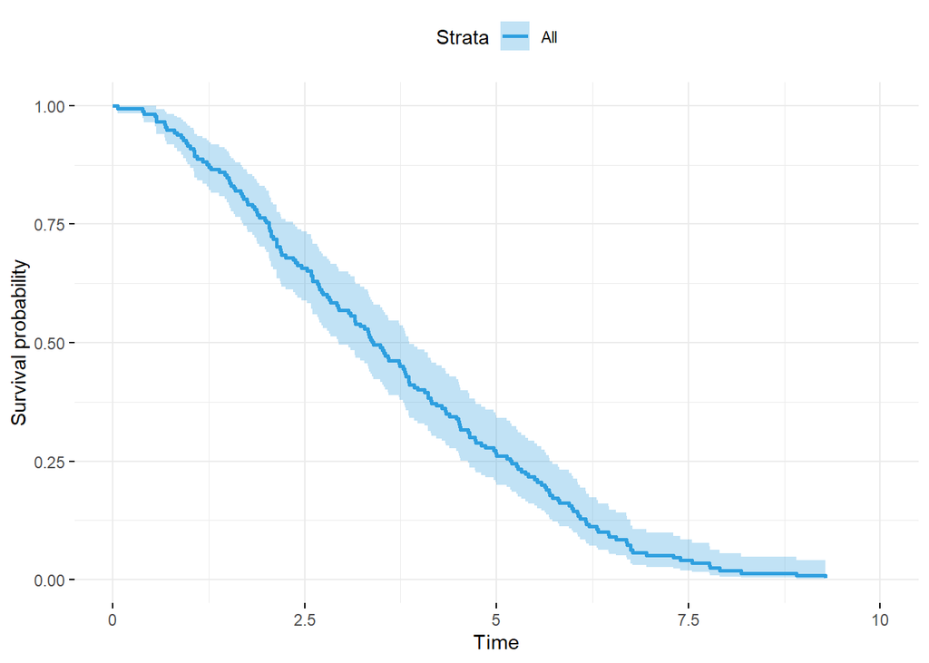

```r
ggsurvplot(survfit(res.cox_vac), data = data, palette = "#2E9FDF",
           ggtheme = theme_minimal())
```

### hos=2 vac ==2

- hos=2:
- vac>1 means: ≥21 days after first vaccination dose with or without second vaccination dose
- same as above >2 doesn’t work

```r
#skewed data
res.cox_vac <- coxph(Surv(time_skewed,vac)~variant, data = data[data$hos==2 & data$vac==2,])
summary(res.cox_vac)
```

```
## Call:
## coxph(formula = Surv(time_skewed, vac) ~ variant, data = data[data$hos ==
##     2 & data$vac == 2, ])
##
##   n= 303, number of events= 303
##
##                 coef exp(coef) se(coef)     z Pr(>|z|)
## variantdelta 0.09887   1.10392  0.12343 0.801    0.423
##
##              exp(coef) exp(-coef) lower .95 upper .95
## variantdelta     1.104     0.9059    0.8667     1.406
##
## Concordance= 0.517  (se = 0.016 )
## Likelihood ratio test= 0.63  on 1 df,   p=0.4
## Wald test            = 0.64  on 1 df,   p=0.4
## Score (logrank) test = 0.64  on 1 df,   p=0.4
```

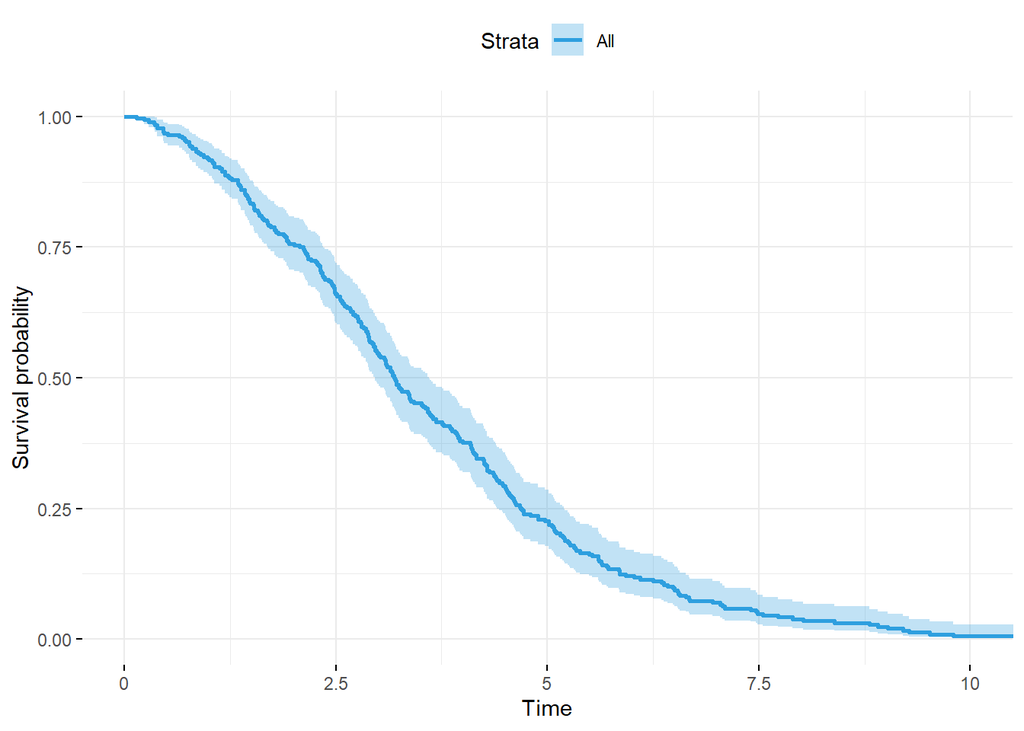

```r
ggsurvplot(survfit(res.cox_vac), data = data, palette = "#2E9FDF",
           ggtheme = theme_minimal())
```

### used hos=2 and vac_update == 1

```r
#skewed data
#skewed data
res.cox_vac <- coxph(Surv(time_skewed,vac_update)~variant, data = data[data$hos==2 & data$vac_update == 1,])
summary(res.cox_vac)
```

```
## Call:
## coxph(formula = Surv(time_skewed, vac_update) ~ variant, data = data[data$hos ==
##     2 & data$vac_update == 1, ])
##
##   n= 1311, number of events= 1311
##
##                 coef exp(coef) se(coef)     z Pr(>|z|)
## variantdelta 0.12684   1.13524  0.06089 2.083   0.0373 *
## ---
## Signif. codes:  0 '***' 0.001 '**' 0.01 '*' 0.05 '.' 0.1 ' ' 1
##
##              exp(coef) exp(-coef) lower .95 upper .95
## variantdelta     1.135     0.8809     1.008     1.279
##
## Concordance= 0.511  (se = 0.007 )
## Likelihood ratio test= 4.26  on 1 df,   p=0.04
## Wald test            = 4.34  on 1 df,   p=0.04
## Score (logrank) test = 4.34  on 1 df,   p=0.04
```

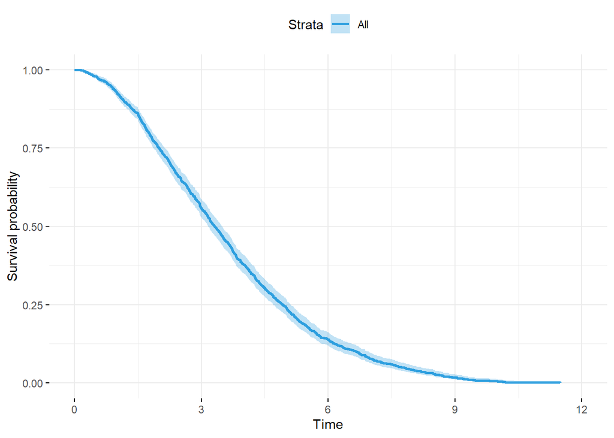

```r
ggsurvplot(survfit(res.cox_vac), data = data, palette = "#2E9FDF",
           ggtheme = theme_minimal())
```

### used hos=2 and vac_update == 2

```r
#skewed data
#skewed data
res.cox_vac <- coxph(Surv(time_skewed,vac_update)~variant, data = data[data$hos==2 & data$vac_update == 2,])
summary(res.cox_vac)
```

```
## Call:
## coxph(formula = Surv(time_skewed, vac_update) ~ variant, data = data[data$hos ==
##     2 & data$vac_update == 2, ])
##
##   n= 335, number of events= 335
##
##                 coef exp(coef) se(coef)     z Pr(>|z|)
## variantdelta 0.07264   1.07534  0.11549 0.629    0.529
##
##              exp(coef) exp(-coef) lower .95 upper .95
## variantdelta     1.075     0.9299    0.8575     1.349
##
## Concordance= 0.516  (se = 0.015 )
## Likelihood ratio test= 0.39  on 1 df,   p=0.5
## Wald test            = 0.4  on 1 df,   p=0.5
## Score (logrank) test = 0.4  on 1 df,   p=0.5
```

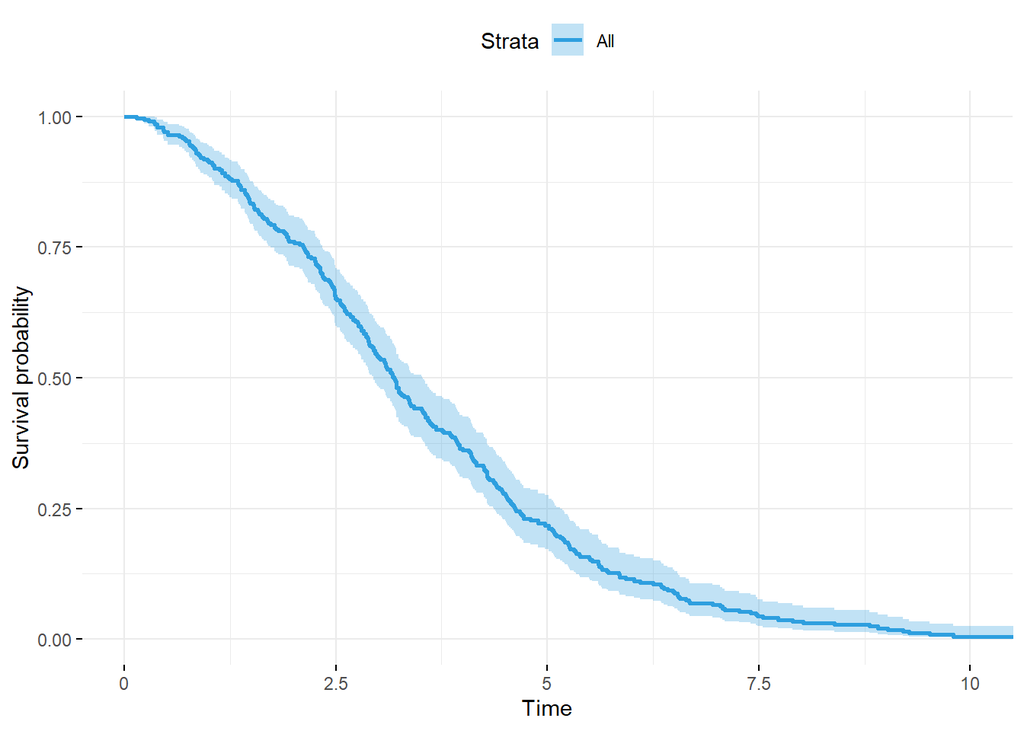

```r
ggsurvplot(survfit(res.cox_vac), data = data, palette = "#2E9FDF",
           ggtheme = theme_minimal())
```